# Risk Factor Analysis

## Outcome Variable

**Outcome Variable:** wasted

## Predictor Variables

**Intervention Variable:** impfloor

**Adjustment Set:**

- arm
- sex
- W_mage
- meducyrs
- feducyrs
- hhwealth_quart
- hfoodsec
- W_mhtcm
- W_mwtkg
- W_mbmi
- W_nrooms
- W_nchldlt5
- W_parity
- impsan
- safeh20
- delta_W_mage
- delta_meducyrs
- delta_feducyrs
- delta_hhwealth_quart
- delta_hfoodsec
- delta_W_mhtcm
- delta_W_mwtkg
- delta_W_mbmi
- delta_W_nrooms
- delta_W_nchldlt5
- delta_W_parity
- delta_impsan
- delta_safeh20

## Stratifying Variables

The analysis was stratified on these variable(s):

- agecat
- studyid
- country

## Data Summary

| agecat | studyid | country | impfloor | wasted | n_cell | n |
| --- | --- | --- | --- | --- | --- | --- |
| Birth | CMC-V-BCS-2002 | INDIA | 1 | 0 | 59 | 68 |
| Birth | CMC-V-BCS-2002 | INDIA | 1 | 1 | 9 | 68 |
| Birth | CMC-V-BCS-2002 | INDIA | 0 | 0 | 0 | 68 |
| Birth | CMC-V-BCS-2002 | INDIA | 0 | 1 | 0 | 68 |
| Birth | CONTENT | PERU | 1 | 0 | 2 | 2 |
| Birth | CONTENT | PERU | 1 | 1 | 0 | 2 |
| Birth | CONTENT | PERU | 0 | 0 | 0 | 2 |
| Birth | CONTENT | PERU | 0 | 1 | 0 | 2 |
| Birth | GMS-Nepal | NEPAL | 1 | 0 | 79 | 503 |
| Birth | GMS-Nepal | NEPAL | 1 | 1 | 18 | 503 |
| Birth | GMS-Nepal | NEPAL | 0 | 0 | 329 | 503 |
| Birth | GMS-Nepal | NEPAL | 0 | 1 | 77 | 503 |
| Birth | IRC | INDIA | 1 | 0 | 190 | 253 |
| Birth | IRC | INDIA | 1 | 1 | 63 | 253 |
| Birth | IRC | INDIA | 0 | 0 | 0 | 253 |
| Birth | IRC | INDIA | 0 | 1 | 0 | 253 |
| Birth | JiVitA-3 | BANGLADESH | 1 | 0 | 1083 | 17966 |
| Birth | JiVitA-3 | BANGLADESH | 1 | 1 | 132 | 17966 |
| Birth | JiVitA-3 | BANGLADESH | 0 | 0 | 14915 | 17966 |
| Birth | JiVitA-3 | BANGLADESH | 0 | 1 | 1836 | 17966 |
| Birth | JiVitA-4 | BANGLADESH | 1 | 0 | 246 | 2394 |
| Birth | JiVitA-4 | BANGLADESH | 1 | 1 | 25 | 2394 |
| Birth | JiVitA-4 | BANGLADESH | 0 | 0 | 1910 | 2394 |
| Birth | JiVitA-4 | BANGLADESH | 0 | 1 | 213 | 2394 |
| Birth | MAL-ED | BANGLADESH | 1 | 0 | 150 | 201 |
| Birth | MAL-ED | BANGLADESH | 1 | 1 | 35 | 201 |
| Birth | MAL-ED | BANGLADESH | 0 | 0 | 16 | 201 |
| Birth | MAL-ED | BANGLADESH | 0 | 1 | 0 | 201 |
| Birth | MAL-ED | BRAZIL | 1 | 0 | 53 | 57 |
| Birth | MAL-ED | BRAZIL | 1 | 1 | 2 | 57 |

[output cut: 162 more lines]

The following strata were considered:

- agecat: 24 months, studyid: CMC-V-BCS-2002, country: INDIA
- agecat: 24 months, studyid: CONTENT, country: PERU
- agecat: 24 months, studyid: GMS-Nepal, country: NEPAL
- agecat: 24 months, studyid: IRC, country: INDIA
- agecat: 24 months, studyid: JiVitA-3, country: BANGLADESH
- agecat: 24 months, studyid: JiVitA-4, country: BANGLADESH
- agecat: 24 months, studyid: MAL-ED, country: BANGLADESH
- agecat: 24 months, studyid: MAL-ED, country: BRAZIL
- agecat: 24 months, studyid: MAL-ED, country: INDIA
- agecat: 24 months, studyid: MAL-ED, country: NEPAL
- agecat: 24 months, studyid: MAL-ED, country: PERU
- agecat: 24 months, studyid: MAL-ED, country: SOUTH AFRICA
- agecat: 24 months, studyid: MAL-ED, country: TANZANIA, UNITED REPUBLIC OF
- agecat: 24 months, studyid: NIH-Birth, country: BANGLADESH
- agecat: 24 months, studyid: NIH-Crypto, country: BANGLADESH
- agecat: 24 months, studyid: PROVIDE, country: BANGLADESH
- agecat: 6 months, studyid: CMC-V-BCS-2002, country: INDIA
- agecat: 6 months, studyid: CONTENT, country: PERU
- agecat: 6 months, studyid: GMS-Nepal, country: NEPAL
- agecat: 6 months, studyid: IRC, country: INDIA
- agecat: 6 months, studyid: JiVitA-3, country: BANGLADESH
- agecat: 6 months, studyid: JiVitA-4, country: BANGLADESH
- agecat: 6 months, studyid: MAL-ED, country: BANGLADESH
- agecat: 6 months, studyid: MAL-ED, country: BRAZIL
- agecat: 6 months, studyid: MAL-ED, country: INDIA
- agecat: 6 months, studyid: MAL-ED, country: NEPAL
- agecat: 6 months, studyid: MAL-ED, country: PERU
- agecat: 6 months, studyid: MAL-ED, country: SOUTH AFRICA
- agecat: 6 months, studyid: MAL-ED, country: TANZANIA, UNITED REPUBLIC OF
- agecat: 6 months, studyid: NIH-Birth, country: BANGLADESH
- agecat: 6 months, studyid: NIH-Crypto, country: BANGLADESH
- agecat: 6 months, studyid: PROVIDE, country: BANGLADESH
- agecat: Birth, studyid: CMC-V-BCS-2002, country: INDIA
- agecat: Birth, studyid: CONTENT, country: PERU
- agecat: Birth, studyid: GMS-Nepal, country: NEPAL
- agecat: Birth, studyid: IRC, country: INDIA
- agecat: Birth, studyid: JiVitA-3, country: BANGLADESH
- agecat: Birth, studyid: JiVitA-4, country: BANGLADESH
- agecat: Birth, studyid: MAL-ED, country: BANGLADESH
- agecat: Birth, studyid: MAL-ED, country: BRAZIL
- agecat: Birth, studyid: MAL-ED, country: INDIA
- agecat: Birth, studyid: MAL-ED, country: NEPAL
- agecat: Birth, studyid: MAL-ED, country: PERU
- agecat: Birth, studyid: MAL-ED, country: SOUTH AFRICA
- agecat: Birth, studyid: MAL-ED, country: TANZANIA, UNITED REPUBLIC OF
- agecat: Birth, studyid: NIH-Birth, country: BANGLADESH
- agecat: Birth, studyid: NIH-Crypto, country: BANGLADESH
- agecat: Birth, studyid: PROVIDE, country: BANGLADESH

### Dropped Strata

Some strata were dropped due to rare outcomes:

- agecat: Birth, studyid: CMC-V-BCS-2002, country: INDIA
- agecat: Birth, studyid: CONTENT, country: PERU
- agecat: Birth, studyid: IRC, country: INDIA
- agecat: Birth, studyid: MAL-ED, country: BANGLADESH
- agecat: Birth, studyid: MAL-ED, country: BRAZIL
- agecat: Birth, studyid: MAL-ED, country: INDIA
- agecat: Birth, studyid: MAL-ED, country: NEPAL
- agecat: Birth, studyid: MAL-ED, country: PERU
- agecat: Birth, studyid: MAL-ED, country: SOUTH AFRICA
- agecat: Birth, studyid: MAL-ED, country: TANZANIA, UNITED REPUBLIC OF
- agecat: 6 months, studyid: CMC-V-BCS-2002, country: INDIA
- agecat: 6 months, studyid: CONTENT, country: PERU
- agecat: 6 months, studyid: IRC, country: INDIA
- agecat: 6 months, studyid: MAL-ED, country: BANGLADESH
- agecat: 6 months, studyid: MAL-ED, country: BRAZIL
- agecat: 6 months, studyid: MAL-ED, country: INDIA
- agecat: 6 months, studyid: MAL-ED, country: NEPAL
- agecat: 6 months, studyid: MAL-ED, country: PERU
- agecat: 6 months, studyid: MAL-ED, country: SOUTH AFRICA
- agecat: 6 months, studyid: MAL-ED, country: TANZANIA, UNITED REPUBLIC OF
- agecat: 6 months, studyid: PROVIDE, country: BANGLADESH
- agecat: 24 months, studyid: CMC-V-BCS-2002, country: INDIA
- agecat: 24 months, studyid: CONTENT, country: PERU
- agecat: 24 months, studyid: IRC, country: INDIA
- agecat: 24 months, studyid: MAL-ED, country: BANGLADESH
- agecat: 24 months, studyid: MAL-ED, country: BRAZIL
- agecat: 24 months, studyid: MAL-ED, country: INDIA
- agecat: 24 months, studyid: MAL-ED, country: NEPAL
- agecat: 24 months, studyid: MAL-ED, country: PERU
- agecat: 24 months, studyid: MAL-ED, country: SOUTH AFRICA
- agecat: 24 months, studyid: MAL-ED, country: TANZANIA, UNITED REPUBLIC OF

## Methods Detail

We’re interested in the causal parameters $E[Y_a]$ for all values of $a \in \mathcal{A}$. These parameters represent the mean outcome if, possibly contrary to fact, we intervened to set all units to have $A=a$. Under the randomization and positivity assumptions, these are identified by the statistical parameters $\psi_a=E_W[E_{Y|A,W}(Y|A=a,W)]$. In addition, we’re interested in the mean of $Y$, $E[Y]$ under no intervention (the observed mean). We will estimate these parameters by using SuperLearner to fit the relevant likelihood factors – $E_{Y|A,W}(Y|A=a,W)$ and $p(A=a|W)$, and then updating our likelihood fit using a joint TMLE.

For unadjusted analyses ($W=\{\}$), initial likelihoods were estimated using Lrnr_glm to estimate the simple $E(Y|A)$ and Lrnr_mean to estimate $p(A)$. For adjusted analyses, a small library containing Lrnr_glmnet, Lrnr_xgboost, and Lrnr_mean was used.

Having estimated these parameters, we will then use the delta method to estimate relative risks and attributable risks relative to a prespecified baseline level of $A$.

# Results Detail

## Results Plots

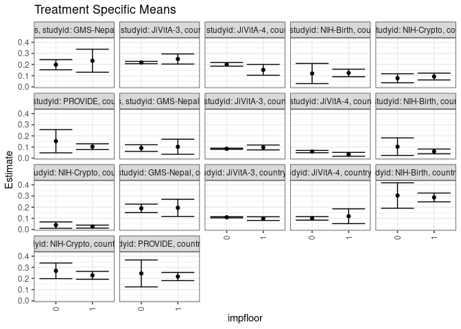

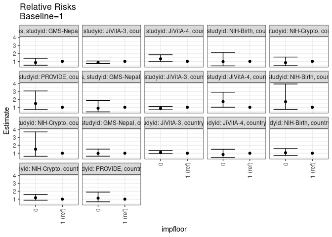

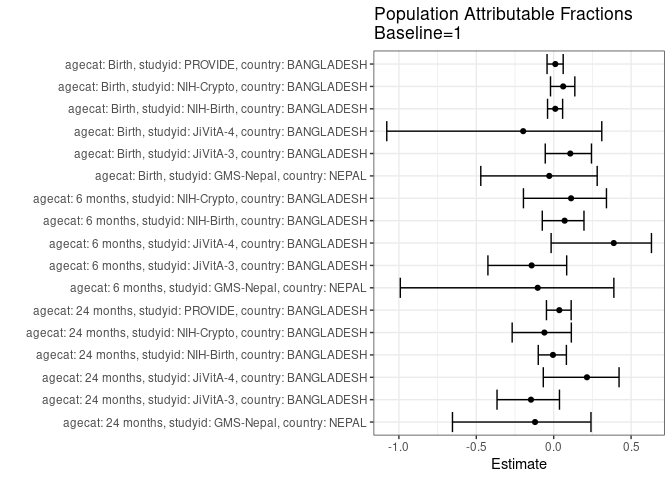

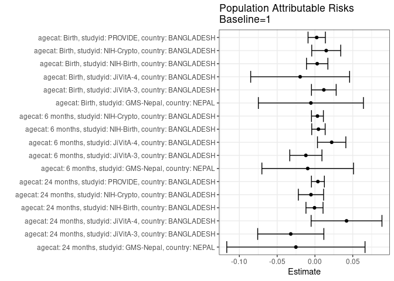

## Results Table

### Parameter: TSM

| agecat | studyid | country | intervention_level | baseline_level | estimate | ci_lower | ci_upper |
| --- | --- | --- | --- | --- | --- | --- | --- |
| Birth | GMS-Nepal | NEPAL | 1 | NA | 0.1942322 | 0.1172564 | 0.2712080 |
| Birth | GMS-Nepal | NEPAL | 0 | NA | 0.1895173 | 0.1513491 | 0.2276856 |
| Birth | JiVitA-3 | BANGLADESH | 1 | NA | 0.0977987 | 0.0813001 | 0.1142972 |
| Birth | JiVitA-3 | BANGLADESH | 0 | NA | 0.1095526 | 0.1041782 | 0.1149270 |
| Birth | JiVitA-4 | BANGLADESH | 1 | NA | 0.1189959 | 0.0525975 | 0.1853943 |
| Birth | JiVitA-4 | BANGLADESH | 0 | NA | 0.0999554 | 0.0838479 | 0.1160629 |
| Birth | NIH-Birth | BANGLADESH | 1 | NA | 0.2872431 | 0.2477140 | 0.3267722 |
| Birth | NIH-Birth | BANGLADESH | 0 | NA | 0.3044437 | 0.1905147 | 0.4183727 |
| Birth | NIH-Crypto | BANGLADESH | 1 | NA | 0.2283744 | 0.1929209 | 0.2638279 |
| Birth | NIH-Crypto | BANGLADESH | 0 | NA | 0.2686938 | 0.1985554 | 0.3388322 |
| Birth | PROVIDE | BANGLADESH | 1 | NA | 0.2175936 | 0.1808659 | 0.2543213 |
| Birth | PROVIDE | BANGLADESH | 0 | NA | 0.2452778 | 0.1247764 | 0.3657793 |
| 6 months | GMS-Nepal | NEPAL | 1 | NA | 0.1025641 | 0.0351589 | 0.1699693 |
| 6 months | GMS-Nepal | NEPAL | 0 | NA | 0.0909091 | 0.0613020 | 0.1205161 |
| 6 months | JiVitA-3 | BANGLADESH | 1 | NA | 0.0964048 | 0.0745657 | 0.1182439 |
| 6 months | JiVitA-3 | BANGLADESH | 0 | NA | 0.0841396 | 0.0790102 | 0.0892689 |
| 6 months | JiVitA-4 | BANGLADESH | 1 | NA | 0.0348731 | 0.0175359 | 0.0522103 |
| 6 months | JiVitA-4 | BANGLADESH | 0 | NA | 0.0596697 | 0.0493349 | 0.0700045 |
| 6 months | NIH-Birth | BANGLADESH | 1 | NA | 0.0607966 | 0.0393324 | 0.0822608 |
| 6 months | NIH-Birth | BANGLADESH | 0 | NA | 0.1034483 | 0.0249989 | 0.1818977 |
| 6 months | NIH-Crypto | BANGLADESH | 1 | NA | 0.0260708 | 0.0125841 | 0.0395575 |
| 6 months | NIH-Crypto | BANGLADESH | 0 | NA | 0.0393258 | 0.0107520 | 0.0678997 |
| 24 months | GMS-Nepal | NEPAL | 1 | NA | 0.2343164 | 0.1313574 | 0.3372754 |
| 24 months | GMS-Nepal | NEPAL | 0 | NA | 0.1989102 | 0.1536102 | 0.2442102 |
| 24 months | JiVitA-3 | BANGLADESH | 1 | NA | 0.2499322 | 0.2047321 | 0.2951322 |
| 24 months | JiVitA-3 | BANGLADESH | 0 | NA | 0.2183810 | 0.2080468 | 0.2287153 |
| 24 months | JiVitA-4 | BANGLADESH | 1 | NA | 0.1527576 | 0.1043931 | 0.2011221 |
| 24 months | JiVitA-4 | BANGLADESH | 0 | NA | 0.2019392 | 0.1855942 | 0.2182841 |
| 24 months | NIH-Birth | BANGLADESH | 1 | NA | 0.1250000 | 0.0915325 | 0.1584675 |
| 24 months | NIH-Birth | BANGLADESH | 0 | NA | 0.1200000 | 0.0298210 | 0.2101790 |
| 24 months | NIH-Crypto | BANGLADESH | 1 | NA | 0.0928068 | 0.0622260 | 0.1233876 |
| 24 months | NIH-Crypto | BANGLADESH | 0 | NA | 0.0773541 | 0.0372513 | 0.1174569 |
| 24 months | PROVIDE | BANGLADESH | 1 | NA | 0.1031895 | 0.0773414 | 0.1290376 |
| 24 months | PROVIDE | BANGLADESH | 0 | NA | 0.1521739 | 0.0482853 | 0.2560625 |

### Parameter: E(Y)

| agecat | studyid | country | intervention_level | baseline_level | estimate | ci_lower | ci_upper |
| --- | --- | --- | --- | --- | --- | --- | --- |
| Birth | GMS-Nepal | NEPAL | NA | NA | 0.1888668 | 0.1546279 | 0.2231057 |
| Birth | JiVitA-3 | BANGLADESH | NA | NA | 0.1095402 | 0.1044185 | 0.1146620 |
| Birth | JiVitA-4 | BANGLADESH | NA | NA | 0.0994152 | 0.0840401 | 0.1147903 |
| Birth | NIH-Birth | BANGLADESH | NA | NA | 0.2902098 | 0.2529834 | 0.3274362 |
| Birth | NIH-Crypto | BANGLADESH | NA | NA | 0.2432815 | 0.2116319 | 0.2749310 |
| Birth | PROVIDE | BANGLADESH | NA | NA | 0.2199248 | 0.1846953 | 0.2551543 |
| 6 months | GMS-Nepal | NEPAL | NA | NA | 0.0929705 | 0.0658371 | 0.1201040 |
| 6 months | JiVitA-3 | BANGLADESH | NA | NA | 0.0843784 | 0.0795716 | 0.0891851 |
| 6 months | JiVitA-4 | BANGLADESH | NA | NA | 0.0569830 | 0.0481380 | 0.0658280 |
| 6 months | NIH-Birth | BANGLADESH | NA | NA | 0.0654206 | 0.0444484 | 0.0863927 |
| 6 months | NIH-Crypto | BANGLADESH | NA | NA | 0.0293706 | 0.0169860 | 0.0417552 |
| 24 months | GMS-Nepal | NEPAL | NA | NA | 0.2091153 | 0.1677890 | 0.2504415 |
| 24 months | JiVitA-3 | BANGLADESH | NA | NA | 0.2179487 | 0.2080959 | 0.2278016 |
| 24 months | JiVitA-4 | BANGLADESH | NA | NA | 0.1945443 | 0.1813282 | 0.2077604 |
| 24 months | NIH-Birth | BANGLADESH | NA | NA | 0.1244131 | 0.0930343 | 0.1557919 |
| 24 months | NIH-Crypto | BANGLADESH | NA | NA | 0.0875486 | 0.0630907 | 0.1120065 |
| 24 months | PROVIDE | BANGLADESH | NA | NA | 0.1070812 | 0.0818727 | 0.1322897 |

### Parameter: RR

| agecat | studyid | country | intervention_level | baseline_level | estimate | ci_lower | ci_upper |
| --- | --- | --- | --- | --- | --- | --- | --- |
| Birth | GMS-Nepal | NEPAL | 1 | 1 | 1.0000000 | 1.0000000 | 1.000000 |
| Birth | GMS-Nepal | NEPAL | 0 | 1 | 0.9757253 | 0.6256549 | 1.521669 |
| Birth | JiVitA-3 | BANGLADESH | 1 | 1 | 1.0000000 | 1.0000000 | 1.000000 |
| Birth | JiVitA-3 | BANGLADESH | 0 | 1 | 1.1201855 | 0.9390159 | 1.336309 |
| Birth | JiVitA-4 | BANGLADESH | 1 | 1 | 1.0000000 | 1.0000000 | 1.000000 |
| Birth | JiVitA-4 | BANGLADESH | 0 | 1 | 0.8399901 | 0.4699517 | 1.501395 |
| Birth | NIH-Birth | BANGLADESH | 1 | 1 | 1.0000000 | 1.0000000 | 1.000000 |
| Birth | NIH-Birth | BANGLADESH | 0 | 1 | 1.0598819 | 0.7116201 | 1.578580 |
| Birth | NIH-Crypto | BANGLADESH | 1 | 1 | 1.0000000 | 1.0000000 | 1.000000 |
| Birth | NIH-Crypto | BANGLADESH | 0 | 1 | 1.1765494 | 0.8695261 | 1.591980 |
| Birth | PROVIDE | BANGLADESH | 1 | 1 | 1.0000000 | 1.0000000 | 1.000000 |
| Birth | PROVIDE | BANGLADESH | 0 | 1 | 1.1272292 | 0.6711039 | 1.893367 |
| 6 months | GMS-Nepal | NEPAL | 1 | 1 | 1.0000000 | 1.0000000 | 1.000000 |
| 6 months | GMS-Nepal | NEPAL | 0 | 1 | 0.8863636 | 0.4256670 | 1.845669 |
| 6 months | JiVitA-3 | BANGLADESH | 1 | 1 | 1.0000000 | 1.0000000 | 1.000000 |
| 6 months | JiVitA-3 | BANGLADESH | 0 | 1 | 0.8727734 | 0.6910618 | 1.102265 |
| 6 months | JiVitA-4 | BANGLADESH | 1 | 1 | 1.0000000 | 1.0000000 | 1.000000 |
| 6 months | JiVitA-4 | BANGLADESH | 0 | 1 | 1.7110515 | 1.0090570 | 2.901419 |
| 6 months | NIH-Birth | BANGLADESH | 1 | 1 | 1.0000000 | 1.0000000 | 1.000000 |
| 6 months | NIH-Birth | BANGLADESH | 0 | 1 | 1.7015458 | 0.7371519 | 3.927628 |
| 6 months | NIH-Crypto | BANGLADESH | 1 | 1 | 1.0000000 | 1.0000000 | 1.000000 |
| 6 months | NIH-Crypto | BANGLADESH | 0 | 1 | 1.5084270 | 0.6182469 | 3.680329 |
| 24 months | GMS-Nepal | NEPAL | 1 | 1 | 1.0000000 | 1.0000000 | 1.000000 |
| 24 months | GMS-Nepal | NEPAL | 0 | 1 | 0.8488959 | 0.5170878 | 1.393621 |
| 24 months | JiVitA-3 | BANGLADESH | 1 | 1 | 1.0000000 | 1.0000000 | 1.000000 |
| 24 months | JiVitA-3 | BANGLADESH | 0 | 1 | 0.8737611 | 0.7275978 | 1.049286 |
| 24 months | JiVitA-4 | BANGLADESH | 1 | 1 | 1.0000000 | 1.0000000 | 1.000000 |
| 24 months | JiVitA-4 | BANGLADESH | 0 | 1 | 1.3219585 | 0.9556246 | 1.828725 |
| 24 months | NIH-Birth | BANGLADESH | 1 | 1 | 1.0000000 | 1.0000000 | 1.000000 |
| 24 months | NIH-Birth | BANGLADESH | 0 | 1 | 0.9600000 | 0.4323222 | 2.131743 |
| 24 months | NIH-Crypto | BANGLADESH | 1 | 1 | 1.0000000 | 1.0000000 | 1.000000 |
| 24 months | NIH-Crypto | BANGLADESH | 0 | 1 | 0.8334963 | 0.4504417 | 1.542300 |
| 24 months | PROVIDE | BANGLADESH | 1 | 1 | 1.0000000 | 1.0000000 | 1.000000 |
| 24 months | PROVIDE | BANGLADESH | 0 | 1 | 1.4747036 | 0.7126652 | 3.051574 |

### Parameter: PAR

| agecat | studyid | country | intervention_level | baseline_level | estimate | ci_lower | ci_upper |
| --- | --- | --- | --- | --- | --- | --- | --- |
| Birth | GMS-Nepal | NEPAL | 1 | NA | -0.0053654 | -0.0748630 | 0.0641321 |
| Birth | JiVitA-3 | BANGLADESH | 1 | NA | 0.0117416 | -0.0045997 | 0.0280828 |
| Birth | JiVitA-4 | BANGLADESH | 1 | NA | -0.0195807 | -0.0850069 | 0.0458455 |
| Birth | NIH-Birth | BANGLADESH | 1 | NA | 0.0029667 | -0.0111588 | 0.0170923 |
| Birth | NIH-Crypto | BANGLADESH | 1 | NA | 0.0149070 | -0.0042661 | 0.0340802 |
| Birth | PROVIDE | BANGLADESH | 1 | NA | 0.0023312 | -0.0091239 | 0.0137864 |
| 6 months | GMS-Nepal | NEPAL | 1 | NA | -0.0095936 | -0.0701945 | 0.0510073 |
| 6 months | JiVitA-3 | BANGLADESH | 1 | NA | -0.0120265 | -0.0333115 | 0.0092586 |
| 6 months | JiVitA-4 | BANGLADESH | 1 | NA | 0.0221099 | 0.0033584 | 0.0408614 |
| 6 months | NIH-Birth | BANGLADESH | 1 | NA | 0.0046239 | -0.0042649 | 0.0135127 |
| 6 months | NIH-Crypto | BANGLADESH | 1 | NA | 0.0032999 | -0.0045774 | 0.0111771 |
| 24 months | GMS-Nepal | NEPAL | 1 | NA | -0.0252011 | -0.1166465 | 0.0662442 |
| 24 months | JiVitA-3 | BANGLADESH | 1 | NA | -0.0319835 | -0.0757457 | 0.0117788 |
| 24 months | JiVitA-4 | BANGLADESH | 1 | NA | 0.0417867 | -0.0050607 | 0.0886342 |
| 24 months | NIH-Birth | BANGLADESH | 1 | NA | -0.0005869 | -0.0118777 | 0.0107040 |
| 24 months | NIH-Crypto | BANGLADESH | 1 | NA | -0.0052582 | -0.0219423 | 0.0114260 |
| 24 months | PROVIDE | BANGLADESH | 1 | NA | 0.0038917 | -0.0046819 | 0.0124653 |

### Parameter: PAF

| agecat | studyid | country | intervention_level | baseline_level | estimate | ci_lower | ci_upper |
| --- | --- | --- | --- | --- | --- | --- | --- |
| Birth | GMS-Nepal | NEPAL | 1 | NA | -0.0284085 | -0.4709891 | 0.2810116 |
| Birth | JiVitA-3 | BANGLADESH | 1 | NA | 0.1071897 | -0.0545312 | 0.2441093 |
| Birth | JiVitA-4 | BANGLADESH | 1 | NA | -0.1969590 | -1.0783150 | 0.3106383 |
| Birth | NIH-Birth | BANGLADESH | 1 | NA | 0.0102227 | -0.0396562 | 0.0577085 |
| Birth | NIH-Crypto | BANGLADESH | 1 | NA | 0.0612749 | -0.0205737 | 0.1365593 |
| Birth | PROVIDE | BANGLADESH | 1 | NA | 0.0106001 | -0.0428591 | 0.0613190 |
| 6 months | GMS-Nepal | NEPAL | 1 | NA | -0.1031895 | -0.9908790 | 0.3886986 |
| 6 months | JiVitA-3 | BANGLADESH | 1 | NA | -0.1425301 | -0.4249273 | 0.0839006 |
| 6 months | JiVitA-4 | BANGLADESH | 1 | NA | 0.3880089 | -0.0166111 | 0.6315866 |
| 6 months | NIH-Birth | BANGLADESH | 1 | NA | 0.0706798 | -0.0737150 | 0.1956563 |
| 6 months | NIH-Crypto | BANGLADESH | 1 | NA | 0.1123526 | -0.1953934 | 0.3408714 |
| 24 months | GMS-Nepal | NEPAL | 1 | NA | -0.1205131 | -0.6539015 | 0.2408559 |
| 24 months | JiVitA-3 | BANGLADESH | 1 | NA | -0.1467476 | -0.3660387 | 0.0373405 |
| 24 months | JiVitA-4 | BANGLADESH | 1 | NA | 0.2147929 | -0.0671378 | 0.4222393 |
| 24 months | NIH-Birth | BANGLADESH | 1 | NA | -0.0047170 | -0.0996885 | 0.0820526 |
| 24 months | NIH-Crypto | BANGLADESH | 1 | NA | -0.0600598 | -0.2682746 | 0.1139720 |
| 24 months | PROVIDE | BANGLADESH | 1 | NA | 0.0363433 | -0.0467606 | 0.1128494 |